# Advanced Methods for Regression and Classification - Exercise 8 Experiment - Dzenan Hamzic, TU Wien

#### Helper Functions

```r
RMSE = function(m, o){
  sqrt(mean((m - o)^2))
}
```

#### Load and inspect data

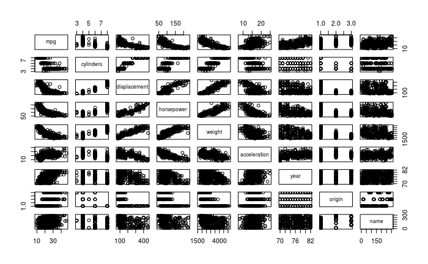

```r
library(ISLR)
library(splines)
library(mgcv)
data(Auto)
plot(Auto)
```

```r
head(Auto)
```

|  | mpg | cylinders | displacement | horsepower | weight | acceleration | year | origin | name |
| --- | --- | --- | --- | --- | --- | --- | --- | --- | --- |
| 1 | 18 | 8 | 307 | 130 | 3504 | 12.0 | 70 | 1 | chevrolet chevelle malibu |
| 2 | 15 | 8 | 350 | 165 | 3693 | 11.5 | 70 | 1 | buick skylark 320 |
| 3 | 18 | 8 | 318 | 150 | 3436 | 11.0 | 70 | 1 | plymouth satellite |
| 4 | 16 | 8 | 304 | 150 | 3433 | 12.0 | 70 | 1 | amc rebel sst |
| 5 | 17 | 8 | 302 | 140 | 3449 | 10.5 | 70 | 1 | ford torino |
| 6 | 15 | 8 | 429 | 198 | 4341 | 10.0 | 70 | 1 | ford galaxie 500 |

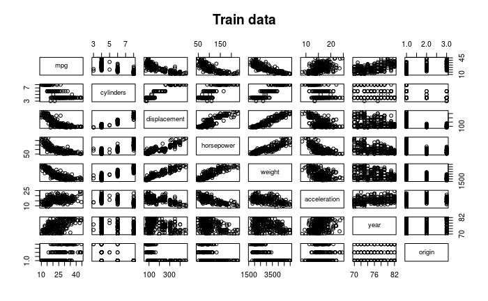

```r
## we do not need car names for prediction purpose
Auto$name <- NULL
set.seed(123)
n <- nrow(Auto)
train <- sample(1:n,round(2/3*n))
test <- c(1:n)[-train]
plot(Auto[train,], main="Train data")
```

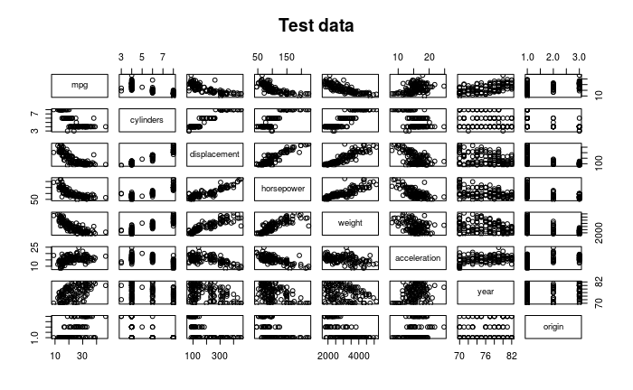

```r
plot(Auto[test,], main="Test data")
```

```r
train_ds <- Auto[train,]
test_ds <- Auto[test,]
```

```r
# empty model
lm0 <- lm(mpg ~ 1, data = train_ds)
# full model
slm <- lm(mpg ~ ., data = train_ds)
summary(slm)
```

```
Call:
lm(formula = mpg ~ ., data = train_ds)

Residuals:
    Min      1Q  Median      3Q     Max
-9.5284 -2.1260  0.1091  1.9740 11.1948

Coefficients:
               Estimate Std. Error t value Pr(>|t|)
(Intercept)  -2.169e+01  5.802e+00  -3.739 0.000229 ***
cylinders    -2.902e-01  3.980e-01  -0.729 0.466561
displacement  1.943e-02  9.951e-03   1.952 0.051985 .
horsepower   -3.035e-03  1.682e-02  -0.181 0.856902
weight       -7.342e-03  8.956e-04  -8.197 1.24e-14 ***
acceleration  1.842e-01  1.200e-01   1.534 0.126199
year          7.923e-01  6.433e-02  12.317  < 2e-16 ***
origin        1.425e+00  3.479e-01   4.096 5.66e-05 ***
---
Signif. codes:  0 ‘***’ 0.001 ‘**’ 0.01 ‘*’ 0.05 ‘.’ 0.1 ‘ ’ 1

Residual standard error: 3.357 on 253 degrees of freedom
Multiple R-squared:  0.8283,    Adjusted R-squared:  0.8236
F-statistic: 174.4 on 7 and 253 DF,  p-value: < 2.2e-16
```

#### RMSE simple linear regression (BASELINE)

```r
# empty model
RMSE(test_ds$mpg, predict.lm(lm0, newdata = test_ds))
```

```
[1] 7.419486
```

```r
# full model
RMSE(test_ds$mpg, predict.lm(slm, newdata = test_ds))
```

```
[1] 3.326522
```

## 1

### 1.a)

```r
lm1 <- lm(mpg ~ cylinders + ns(displacement, df=4) + ns(horsepower, df=4) + ns(weight, df=4) +
            ns(acceleration, df=4) + ns(year, df=4) + ns(origin, df=4), data = train_ds)
summary(lm1)
```

```
Call:
lm(formula = mpg ~ cylinders + ns(displacement, df = 4) + ns(horsepower,
    df = 4) + ns(weight, df = 4) + ns(acceleration, df = 4) +
    ns(year, df = 4) + ns(origin, df = 4), data = train_ds)

Residuals:
    Min      1Q  Median      3Q     Max
-7.6415 -1.4662  0.1703  1.4823  7.6001

Coefficients: (2 not defined because of singularities)
                          Estimate Std. Error t value Pr(>|t|)
(Intercept)                40.1702     3.4648  11.594  < 2e-16 ***
cylinders                   0.3913     0.4423   0.885 0.377199
ns(displacement, df = 4)1  -1.5555     2.4053  -0.647 0.518457
ns(displacement, df = 4)2  -1.5055     3.2266  -0.467 0.641220
ns(displacement, df = 4)3  -0.9203     4.3152  -0.213 0.831304
ns(displacement, df = 4)4  -3.9795     3.4920  -1.140 0.255605
ns(horsepower, df = 4)1    -7.2847     1.8085  -4.028 7.58e-05 ***
ns(horsepower, df = 4)2   -12.1264     2.4399  -4.970 1.28e-06 ***
ns(horsepower, df = 4)3   -20.7882     4.0059  -5.189 4.53e-07 ***
ns(horsepower, df = 4)4   -11.1796     2.6409  -4.233 3.30e-05 ***
ns(weight, df = 4)1        -8.5461     2.1794  -3.921 0.000115 ***
ns(weight, df = 4)2        -8.4074     2.5808  -3.258 0.001288 **
ns(weight, df = 4)3       -12.0465     4.4202  -2.725 0.006903 **
ns(weight, df = 4)4        -6.9901     2.8263  -2.473 0.014093 *
ns(acceleration, df = 4)1  -5.6173     2.4282  -2.313 0.021558 *
ns(acceleration, df = 4)2  -4.9497     1.7814  -2.779 0.005897 **
ns(acceleration, df = 4)3 -10.0962     5.0607  -1.995 0.047184 *
ns(acceleration, df = 4)4  -3.9620     2.3774  -1.667 0.096931 .
ns(year, df = 4)1          -0.3239     0.8920  -0.363 0.716837
ns(year, df = 4)2           6.6721     0.8621   7.740 2.87e-13 ***
ns(year, df = 4)3           6.3139     1.6330   3.867 0.000143 ***
ns(year, df = 4)4           8.2366     0.7326  11.242  < 2e-16 ***
ns(origin, df = 4)1        -2.6123     1.2931  -2.020 0.044493 *
ns(origin, df = 4)2         1.3199     0.9078   1.454 0.147264
ns(origin, df = 4)3             NA         NA      NA       NA
ns(origin, df = 4)4             NA         NA      NA       NA
---
Signif. codes:  0 ‘***’ 0.001 ‘**’ 0.01 ‘*’ 0.05 ‘.’ 0.1 ‘ ’ 1

Residual standard error: 2.623 on 237 degrees of freedom
Multiple R-squared:  0.9018,    Adjusted R-squared:  0.8923
F-statistic: 94.63 on 23 and 237 DF,  p-value: < 2.2e-16
```

The significant variables are: (Intercept) 40.1702 3.4648 11.594 < 2e-16 *, ns(horsepower, df = 4)1 -7.2847 1.8085 -4.028 7.58e-05* , ns(horsepower, df = 4)2 -12.1264 2.4399 -4.970 1.28e-06 *, ns(horsepower, df = 4)3 -20.7882 4.0059 -5.189 4.53e-07* , ns(horsepower, df = 4)4 -11.1796 2.6409 -4.233 3.30e-05 *, ns(weight, df = 4)1 -8.5461 2.1794 -3.921 0.000115* , ns(weight, df = 4)2 -8.4074 2.5808 -3.258 0.001288 ** , ns(weight, df = 4)3 -12.0465 4.4202 -2.725 0.006903 ** , ns(weight, df = 4)4 -6.9901 2.8263 -2.473 0.014093 * , ns(acceleration, df = 4)1 -5.6173 2.4282 -2.313 0.021558 * , ns(acceleration, df = 4)2 -4.9497 1.7814 -2.779 0.005897 ** , ns(acceleration, df = 4)3 -10.0962 5.0607 -1.995 0.047184 * , ns(year, df = 4)2 6.6721 0.8621 7.740 2.87e-13 *, ns(year, df = 4)3 6.3139 1.6330 3.867 0.000143* , ns(year, df = 4)4 8.2366 0.7326 11.242 < 2e-16 ***, ns(origin, df = 4)1 -2.6123 1.2931 -2.020 0.044493*

```r
RMSE(test_ds$mpg, predict.lm(lm1, newdata = test_ds))
```

```
prediction from a rank-deficient fit may be misleading
```

```
[1] 3.020192
```

### 1.b)

```r
step(lm0, direction = "both", scope = formula(lm1))
```

```
Start:  AIC=1086.02
mpg ~ 1

                           Df Sum of Sq     RSS     AIC
+ ns(weight, df = 4)        4   11989.6  4622.0  760.13
+ ns(displacement, df = 4)  4   11599.6  5012.0  781.28
+ ns(horsepower, df = 4)    4   11541.7  5069.9  784.27
+ cylinders                 1    9867.0  6744.6  852.77
+ ns(year, df = 4)          4    6472.8 10138.8  965.16
+ ns(origin, df = 4)        2    5570.2 11041.4  983.41
+ ns(acceleration, df = 4)  4    3597.4 13014.2 1030.32
<none>                                  16611.6 1086.02

Step:  AIC=760.13
mpg ~ ns(weight, df = 4)

                           Df Sum of Sq     RSS     AIC
+ ns(year, df = 4)          4    2566.3  2055.7  556.67
+ ns(horsepower, df = 4)    4     704.3  3917.7  724.98
+ ns(acceleration, df = 4)  4     254.6  4367.4  753.34
+ ns(displacement, df = 4)  4     223.0  4399.0  755.23
+ ns(origin, df = 4)        2      78.0  4544.0  759.69
+ cylinders                 1      37.7  4584.3  759.99
<none>                                   4622.0  760.13
- ns(weight, df = 4)        4   11989.6 16611.6 1086.02

Step:  AIC=556.67
mpg ~ ns(weight, df = 4) + ns(year, df = 4)

                           Df Sum of Sq     RSS    AIC
+ ns(horsepower, df = 4)    4     244.4  1811.4 531.64
+ ns(acceleration, df = 4)  4     142.5  1913.2 545.92
+ ns(origin, df = 4)        2     108.5  1947.3 546.52
<none>                                   2055.7 556.67
+ cylinders                 1      11.7  2044.1 557.18
+ ns(displacement, df = 4)  4      53.2  2002.6 557.83
- ns(year, df = 4)          4    2566.3  4622.0 760.13
- ns(weight, df = 4)        4    8083.1 10138.8 965.16

Step:  AIC=531.64
```

[output cut: 46 more lines]

```
Coefficients:
              (Intercept)        ns(weight, df = 4)1        ns(weight, df = 4)2
                  40.8598                    -8.7266                    -9.3233
      ns(weight, df = 4)3        ns(weight, df = 4)4          ns(year, df = 4)1
                 -12.1931                    -8.7155                    -0.1842
        ns(year, df = 4)2          ns(year, df = 4)3          ns(year, df = 4)4
                   6.6775                     6.2908                     8.4928
  ns(horsepower, df = 4)1    ns(horsepower, df = 4)2    ns(horsepower, df = 4)3
                  -7.1291                   -10.7131                   -19.2469
  ns(horsepower, df = 4)4        ns(origin, df = 4)1        ns(origin, df = 4)2
                 -10.8871                    -3.2491                     1.8468
      ns(origin, df = 4)3        ns(origin, df = 4)4  ns(acceleration, df = 4)1
                       NA                         NA                    -4.7453
ns(acceleration, df = 4)2  ns(acceleration, df = 4)3  ns(acceleration, df = 4)4
                  -4.4335                    -8.4521                    -3.1175
```

#### reduced model

```r
lm2 <- lm(formula = mpg ~ ns(weight, df = 4) + ns(year, df = 4) +
            ns(horsepower, df = 4) + ns(origin, df = 2) + ns(acceleration, df = 4),
    data = train_ds)
summary(lm2)
```

```
Call:
lm(formula = mpg ~ ns(weight, df = 4) + ns(year, df = 4) + ns(horsepower,
    df = 4) + ns(origin, df = 2) + ns(acceleration, df = 4),
    data = train_ds)

Residuals:
    Min      1Q  Median      3Q     Max
-9.0230 -1.3159  0.1003  1.4216  7.5309

Coefficients: (1 not defined because of singularities)
                          Estimate Std. Error t value Pr(>|t|)
(Intercept)                47.3897     3.5856  13.217  < 2e-16 ***
ns(weight, df = 4)1        -8.5066     1.7440  -4.878 1.94e-06 ***
ns(weight, df = 4)2        -9.5221     1.8283  -5.208 4.06e-07 ***
ns(weight, df = 4)3       -12.2856     3.6926  -3.327 0.001013 **
ns(weight, df = 4)4        -8.9866     2.0032  -4.486 1.12e-05 ***
ns(year, df = 4)1          -0.1169     0.8749  -0.134 0.893857
ns(year, df = 4)2           6.5506     0.8386   7.811 1.70e-13 ***
ns(year, df = 4)3           6.1547     1.5988   3.849 0.000151 ***
ns(year, df = 4)4           8.1906     0.6955  11.777  < 2e-16 ***
ns(horsepower, df = 4)1    -7.4711     1.7648  -4.233 3.27e-05 ***
ns(horsepower, df = 4)2   -10.7417     2.2472  -4.780 3.04e-06 ***
ns(horsepower, df = 4)3   -19.3738     3.9015  -4.966 1.29e-06 ***
ns(horsepower, df = 4)4   -10.9931     2.5714  -4.275 2.74e-05 ***
ns(origin, df = 2)1       -14.1503     5.1397  -2.753 0.006349 **
ns(origin, df = 2)2             NA         NA      NA       NA
ns(acceleration, df = 4)1  -4.5320     2.0940  -2.164 0.031415 *
ns(acceleration, df = 4)2  -4.6316     1.5985  -2.897 0.004105 **
ns(acceleration, df = 4)3  -8.0290     4.5144  -1.779 0.076567 .
ns(acceleration, df = 4)4  -2.2460     2.2161  -1.013 0.311837
---
Signif. codes:  0 ‘***’ 0.001 ‘**’ 0.01 ‘*’ 0.05 ‘.’ 0.1 ‘ ’ 1

Residual standard error: 2.639 on 243 degrees of freedom
Multiple R-squared:  0.8981,    Adjusted R-squared:  0.891
F-statistic: 126.1 on 17 and 243 DF,  p-value: < 2.2e-16
```

The significant variables are: (Intercept) 47.3897 3.5856 13.217 < 2e-16 *, ns(weight, df = 4)1 -8.5066 1.7440 -4.878 1.94e-06* , ns(weight, df = 4)2 -9.5221 1.8283 -5.208 4.06e-07 **, ns(weight, df = 4)3 -12.2856 3.6926 -3.327 0.001013** , ns(weight, df = 4)4 -8.9866 2.0032 -4.486 1.12e-05 **, ns(year, df = 4)2 6.5506 0.8386 7.811 1.70e-13** *, ns(year, df = 4)3 6.1547 1.5988 3.849 0.000151* **, ns(year, df = 4)4 8.1906 0.6955 11.777 < 2e-16** *, ns(horsepower, df = 4)1 -7.4711 1.7648 -4.233 3.27e-05* **, ns(horsepower, df = 4)2 -10.7417 2.2472 -4.780 3.04e-06** *, ns(horsepower, df = 4)3 -19.3738 3.9015 -4.966 1.29e-06* **, ns(horsepower, df = 4)4 -10.9931 2.5714 -4.275 2.74e-05** *, ns(origin, df = 2)1 -14.1503 5.1397 -2.753 0.006349 **, ns(acceleration, df = 4)1 -4.5320 2.0940 -2.164 0.031415 * , ns(acceleration, df = 4)2 -4.6316 1.5985 -2.897 0.004105**

```r
RMSE(test_ds$mpg, predict.lm(lm2, newdata = test_ds))
```

```
prediction from a rank-deficient fit may be misleading
```

```
[1] 2.961206
```

### 1.c)

These plots show how individual variables contribute to the “mpg” consumption in the model.

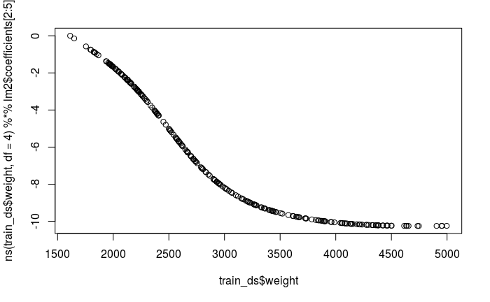

```r
#plot(train_ds$weight)
plot(train_ds$weight, ns(train_ds$weight, df = 4)%*%lm2$coefficients[2:5])
```

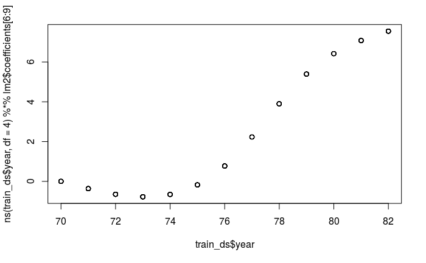

```r
plot(train_ds$year, ns(train_ds$year, df = 4)%*%lm2$coefficients[6:9])
```

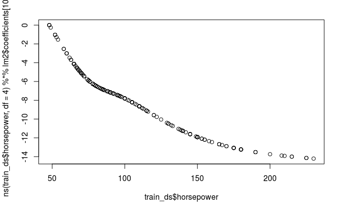

```r
plot(train_ds$horsepower, ns(train_ds$horsepower, df = 4)%*%lm2$coefficients[10:13])
```

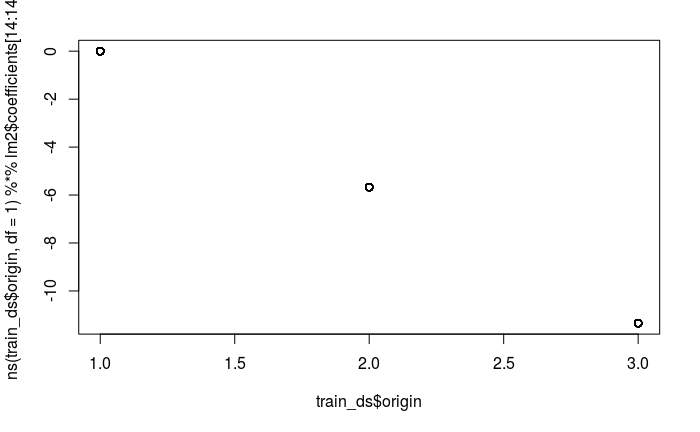

```r
plot(train_ds$origin, ns(train_ds$origin, df = 1)%*%lm2$coefficients[14:14])
```

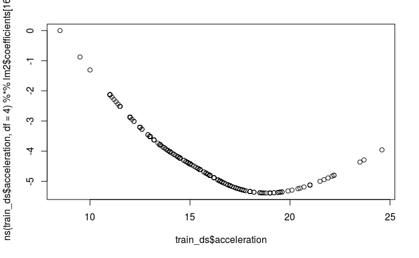

```r
plot(train_ds$acceleration, ns(train_ds$acceleration, df = 4)%*%lm2$coefficients[16:19])
```

## 2

### 2.a)

```r
mod.gam <- gam(mpg ~ cylinders + s(displacement) + s(horsepower) + s(weight)
               + s(acceleration) + s(year) + origin, data = train_ds)
summary(mod.gam)
```

```
Family: gaussian
Link function: identity

Formula:
mpg ~ cylinders + s(displacement) + s(horsepower) + s(weight) +
    s(acceleration) + s(year) + origin

Parametric coefficients:
            Estimate Std. Error t value Pr(>|t|)
(Intercept)  21.4749     1.9928  10.776   <2e-16 ***
cylinders     0.1965     0.3611   0.544   0.5868
origin        0.6412     0.2845   2.254   0.0251 *
---
Signif. codes:  0 ‘***’ 0.001 ‘**’ 0.01 ‘*’ 0.05 ‘.’ 0.1 ‘ ’ 1

Approximate significance of smooth terms:
                  edf Ref.df      F  p-value
s(displacement) 1.315  1.543  0.549 0.385032
s(horsepower)   2.863  3.648  5.946 0.000329 ***
s(weight)       2.376  3.037 10.204 2.23e-06 ***
s(acceleration) 2.144  2.756  2.078 0.083199 .
s(year)         8.529  8.931 37.053  < 2e-16 ***
---
Signif. codes:  0 ‘***’ 0.001 ‘**’ 0.01 ‘*’ 0.05 ‘.’ 0.1 ‘ ’ 1

R-sq.(adj) =  0.899   Deviance explained = 90.6%
GCV = 7.0162  Scale est. = 6.4725    n = 261
```

Most significant variables are (consecutive order): s(year) : complexity = 8.53->9, (Intercept), s(weight) : complexity = 2, s(horsepower) : compexity = 3, origin

Other variables are statistically insignificant.

### 2.c)

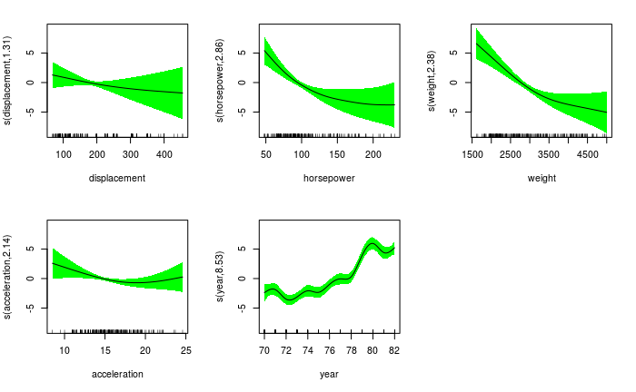

```r
plot(mod.gam, page=1, shade=TRUE, shade.col = "green")
```

The variable “year” is very “non-linear”. Displacement variable is most linear among others. variables “horsepower”, “weight” and “acceleration” have slight nonlinearity. The thicknes of the green area indicates  
prediction error level.

### 2.d)

```r
RMSE(test_ds$mpg, predict(mod.gam, test_ds))
```

```
[1] 2.90203
```

### 2.e)

Try first with reduction of non-linearity with the log scale.

```r
mod.gam1 <- gam(mpg ~ cylinders + s(displacement) + s(horsepower) + s(weight)
               + s(acceleration) + s(log(year)) + origin, data = train_ds)
RMSE(test_ds$mpg, predict(mod.gam1, test_ds))
```

```
[1] 2.86901
```

```r
summary(mod.gam1)
```

```
Family: gaussian
Link function: identity

Formula:
mpg ~ cylinders + s(displacement) + s(horsepower) + s(weight) +
    s(acceleration) + s(log(year)) + origin

Parametric coefficients:
            Estimate Std. Error t value Pr(>|t|)
(Intercept)  21.6792     1.9974  10.854   <2e-16 ***
cylinders     0.1656     0.3622   0.457   0.6479
origin        0.6187     0.2882   2.147   0.0328 *
---
Signif. codes:  0 ‘***’ 0.001 ‘**’ 0.01 ‘*’ 0.05 ‘.’ 0.1 ‘ ’ 1

Approximate significance of smooth terms:
                  edf Ref.df      F  p-value
s(displacement) 1.325  1.558  0.519  0.39583
s(horsepower)   2.575  3.287  5.989  0.00049 ***
s(weight)       2.416  3.078 11.114 6.41e-07 ***
s(acceleration) 2.222  2.856  2.194  0.07092 .
s(log(year))    8.099  8.777 35.912  < 2e-16 ***
---
Signif. codes:  0 ‘***’ 0.001 ‘**’ 0.01 ‘*’ 0.05 ‘.’ 0.1 ‘ ’ 1

R-sq.(adj) =  0.896   Deviance explained = 90.3%
GCV = 7.2007  Scale est. = 6.659     n = 261
```

Now, try with parameter optimization

```r
mod.gam2 <- gam(mpg ~ cylinders + s(displacement) + s(horsepower) + s(weight)
               + s(acceleration) + s(log(year)) + origin, data = train_ds, gamma=2.5, method = "REML", select = TRUE)
RMSE(test_ds$mpg, predict(mod.gam2, test_ds))
```

```
[1] 2.803701
```

FINAL RMSE -> 2.803701

```r
summary(mod.gam2)
```

```
Family: gaussian
Link function: identity

Formula:
mpg ~ cylinders + s(displacement) + s(horsepower) + s(weight) +
    s(acceleration) + s(log(year)) + origin

Parametric coefficients:
            Estimate Std. Error t value Pr(>|t|)
(Intercept) 22.20373    1.59476  13.923  < 2e-16 ***
cylinders    0.01748    0.26633   0.066  0.94774
origin       0.80380    0.27356   2.938  0.00361 **
---
Signif. codes:  0 ‘***’ 0.001 ‘**’ 0.01 ‘*’ 0.05 ‘.’ 0.1 ‘ ’ 1

Approximate significance of smooth terms:
                      edf Ref.df      F  p-value
s(displacement) 0.0009112      9  0.000   0.0890 .
s(horsepower)   2.2673510      9  2.765 4.89e-08 ***
s(weight)       2.7019117      9  8.242  < 2e-16 ***
s(acceleration) 1.1021060      9  0.532   0.0074 **
s(log(year))    2.9192576      9 31.687  < 2e-16 ***
---
Signif. codes:  0 ‘***’ 0.001 ‘**’ 0.01 ‘*’ 0.05 ‘.’ 0.1 ‘ ’ 1

R-sq.(adj) =   0.89   Deviance explained = 89.4%
-REML = 267.43  Scale est. = 7.0544    n = 261
```

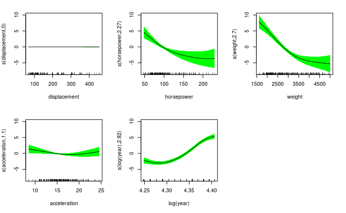

```r
plot(mod.gam2, page=1, shade=TRUE, shade.col = "green")
```

“displacement” predictor’s df got reduced to 0. This variable has no more significance in our model.